# Ethan’s Iris Analysis in RMarkdown

Ethan Hill

2020-01-16

Hello! Here are the plots and the code for the plots I have generated with the Iris dataset. I have also gone ahead and included the workflow I used to get the final plots…

It is always a good habit to set your working directory:

```r
setwd("C:/Users/hille/Documents/Rbootcamp_S2020/Iris-repo/")
```

Next, I’ve scrambled the iris dataset (gotta make it harder) and stored the scrambled data into the object called mix:

```r
oo <- sample(x=1:150, 150, replace=FALSE)
mix <- iris[oo,]
```

Once I have the scrambled data stored in the object called “mix” I can store each of the columns as a seperate vector:

```r
species <- mix$Species
petalL <- mix$Petal.Length
petalW <- mix$Petal.Width
sepalL <- mix$Sepal.Length
sepalW <- mix$Sepal.Width
```

Now that I have each of the columns stored as seperate vectors, I can take the species vector and assign each species its own unique color based on logical operations:

```r
species2 <- species
color2 <- rep("red", 150)
species2 == "setosa"
```

```
##   [1] FALSE FALSE  TRUE FALSE FALSE  TRUE FALSE FALSE  TRUE FALSE FALSE  TRUE FALSE FALSE
##  [15]  TRUE FALSE FALSE FALSE FALSE FALSE FALSE  TRUE  TRUE FALSE FALSE FALSE FALSE  TRUE
##  [29]  TRUE  TRUE FALSE FALSE FALSE FALSE FALSE  TRUE FALSE FALSE FALSE  TRUE FALSE FALSE
##  [43]  TRUE FALSE FALSE FALSE  TRUE FALSE  TRUE FALSE  TRUE FALSE FALSE FALSE  TRUE  TRUE
##  [57]  TRUE FALSE  TRUE  TRUE FALSE  TRUE FALSE  TRUE  TRUE FALSE FALSE  TRUE  TRUE  TRUE
##  [71] FALSE  TRUE FALSE FALSE FALSE FALSE FALSE FALSE  TRUE FALSE FALSE FALSE FALSE FALSE
##  [85] FALSE  TRUE FALSE  TRUE  TRUE FALSE FALSE FALSE  TRUE FALSE  TRUE FALSE FALSE  TRUE
##  [99] FALSE  TRUE  TRUE FALSE FALSE FALSE  TRUE  TRUE  TRUE FALSE FALSE FALSE FALSE FALSE
## [113] FALSE FALSE FALSE  TRUE FALSE FALSE FALSE FALSE FALSE FALSE FALSE  TRUE  TRUE FALSE
## [127] FALSE FALSE FALSE FALSE FALSE  TRUE  TRUE  TRUE FALSE  TRUE FALSE FALSE  TRUE  TRUE
## [141]  TRUE FALSE FALSE FALSE FALSE FALSE FALSE FALSE FALSE FALSE
```

```r
color2[species2 == "setosa"] <- "purple"
color2
```

```
##   [1] "red"    "red"    "purple" "red"    "red"    "purple" "red"    "red"    "purple"
##  [10] "red"    "red"    "purple" "red"    "red"    "purple" "red"    "red"    "red"
##  [19] "red"    "red"    "red"    "purple" "purple" "red"    "red"    "red"    "red"
##  [28] "purple" "purple" "purple" "red"    "red"    "red"    "red"    "red"    "purple"
##  [37] "red"    "red"    "red"    "purple" "red"    "red"    "purple" "red"    "red"
##  [46] "red"    "purple" "red"    "purple" "red"    "purple" "red"    "red"    "red"
##  [55] "purple" "purple" "purple" "red"    "purple" "purple" "red"    "purple" "red"
##  [64] "purple" "purple" "red"    "red"    "purple" "purple" "purple" "red"    "purple"
##  [73] "red"    "red"    "red"    "red"    "red"    "red"    "purple" "red"    "red"
##  [82] "red"    "red"    "red"    "red"    "purple" "red"    "purple" "purple" "red"
##  [91] "red"    "red"    "purple" "red"    "purple" "red"    "red"    "purple" "red"
## [100] "purple" "purple" "red"    "red"    "red"    "purple" "purple" "purple" "red"
## [109] "red"    "red"    "red"    "red"    "red"    "red"    "red"    "purple" "red"
## [118] "red"    "red"    "red"    "red"    "red"    "red"    "purple" "purple" "red"
## [127] "red"    "red"    "red"    "red"    "red"    "purple" "purple" "purple" "red"
## [136] "purple" "red"    "red"    "purple" "purple" "purple" "red"    "red"    "red"
## [145] "red"    "red"    "red"    "red"    "red"    "red"
```

```r
color2[species2 == "versicolor"] <- "blue"
color2
```

```
##   [1] "blue"   "blue"   "purple" "blue"   "blue"   "purple" "red"    "red"    "purple"
##  [10] "blue"   "blue"   "purple" "red"    "red"    "purple" "red"    "blue"   "red"
##  [19] "red"    "blue"   "red"    "purple" "purple" "blue"   "blue"   "red"    "blue"
##  [28] "purple" "purple" "purple" "blue"   "blue"   "red"    "blue"   "blue"   "purple"
##  [37] "red"    "red"    "red"    "purple" "red"    "red"    "purple" "red"    "blue"
##  [46] "red"    "purple" "blue"   "purple" "blue"   "purple" "blue"   "red"    "red"
##  [55] "purple" "purple" "purple" "blue"   "purple" "purple" "blue"   "purple" "blue"
##  [64] "purple" "purple" "red"    "blue"   "purple" "purple" "purple" "red"    "purple"
##  [73] "red"    "blue"   "red"    "red"    "red"    "red"    "purple" "red"    "blue"
##  [82] "red"    "red"    "blue"   "blue"   "purple" "blue"   "purple" "purple" "blue"
##  [91] "blue"   "red"    "purple" "blue"   "purple" "red"    "blue"   "purple" "blue"
## [100] "purple" "purple" "blue"   "red"    "blue"   "purple" "purple" "purple" "blue"
## [109] "red"    "red"    "blue"   "blue"   "red"    "red"    "blue"   "purple" "red"
## [118] "blue"   "red"    "red"    "red"    "blue"   "blue"   "purple" "purple" "red"
## [127] "red"    "red"    "red"    "blue"   "red"    "purple" "purple" "purple" "blue"
## [136] "purple" "red"    "blue"   "purple" "purple" "purple" "blue"   "red"    "red"
## [145] "blue"   "blue"   "blue"   "red"    "red"    "blue"
```

```r
color2[species2 == "virginica"] <- "orange"
color2
```

```
##   [1] "blue"   "blue"   "purple" "blue"   "blue"   "purple" "orange" "orange" "purple"
##  [10] "blue"   "blue"   "purple" "orange" "orange" "purple" "orange" "blue"   "orange"
##  [19] "orange" "blue"   "orange" "purple" "purple" "blue"   "blue"   "orange" "blue"
##  [28] "purple" "purple" "purple" "blue"   "blue"   "orange" "blue"   "blue"   "purple"
##  [37] "orange" "orange" "orange" "purple" "orange" "orange" "purple" "orange" "blue"
##  [46] "orange" "purple" "blue"   "purple" "blue"   "purple" "blue"   "orange" "orange"
##  [55] "purple" "purple" "purple" "blue"   "purple" "purple" "blue"   "purple" "blue"
##  [64] "purple" "purple" "orange" "blue"   "purple" "purple" "purple" "orange" "purple"
##  [73] "orange" "blue"   "orange" "orange" "orange" "orange" "purple" "orange" "blue"
##  [82] "orange" "orange" "blue"   "blue"   "purple" "blue"   "purple" "purple" "blue"
##  [91] "blue"   "orange" "purple" "blue"   "purple" "orange" "blue"   "purple" "blue"
## [100] "purple" "purple" "blue"   "orange" "blue"   "purple" "purple" "purple" "blue"
## [109] "orange" "orange" "blue"   "blue"   "orange" "orange" "blue"   "purple" "orange"
## [118] "blue"   "orange" "orange" "orange" "blue"   "blue"   "purple" "purple" "orange"
## [127] "orange" "orange" "orange" "blue"   "orange" "purple" "purple" "purple" "blue"
## [136] "purple" "orange" "blue"   "purple" "purple" "purple" "blue"   "orange" "orange"
## [145] "blue"   "blue"   "blue"   "orange" "orange" "blue"
```

Cool, Now we can start doing some real analyses. I have have made a best fit line of regression for Sepel Width as a function of Petal Length and have displayed the output stats:

```r
sepalW.lm <- lm(sepalW ~ petalL)
sepalW.lm
```

```
##
## Call:
## lm(formula = sepalW ~ petalL)
##
## Coefficients:
## (Intercept)       petalL
##      3.4549      -0.1058
```

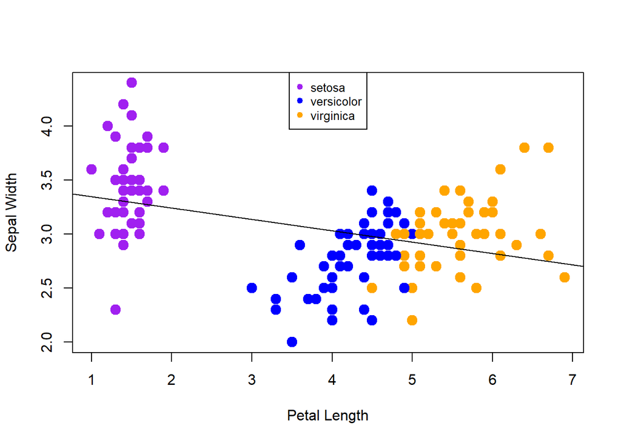

```r
plot(petalL, sepalW, col=color2, cex=1.5, pch=19, xlab="Petal Length", ylab="Sepal Width")
abline(sepalW.lm, col="black")
legend('top', legend = levels(species), col = c("purple", "blue", "orange"), cex = .8, pch = 19)
```

As we can see from the graph above, the “general” trend is that as petal length increases, the sepal width decreases.

BUT WAIT THERE’S MORE!!!!

We can also index the iris dataset by species and make a regression line for Sepel Width as a function of Petal Length FOR EACH SPECIES and we can ALSO calcuate error for the linear regression FOR EACH SPECIES:

```
setosa <- mix[mix$Species == "setosa",]
setosa
setosaPLvsSW.lm <- lm(setosa$Sepal.Width ~ setosa$Petal.Length)
setosaPLvsSW.lm
b.setosa <- coef(setosaPLvsSW.lm)
int.setosa <- b.setosa[1]
slope.setosa <- b.setosa[2]
yhat.setosa <- slope.setosa*setosa$Petal.Length+int.setosa
yhat.setosa
error.setosa.sepalW <- setosa$Sepal.Width-yhat.setosa
error.setosa.sepalW

versicolor <- mix[mix$Species == "versicolor",]
versicolor
versicolorPLvsSW.lm <- lm(versicolor$Sepal.Width ~ versicolor$Petal.Length)
versicolorPLvsSW.lm
b.versicolor <- coef(versicolorPLvsSW.lm)
int.versicolor <- b.versicolor[1]
slope.versicolor <- b.versicolor[2]
yhat.versicolor <- slope.versicolor*versicolor$Petal.Length+int.versicolor
yhat.versicolor
error.versicolor.sepalW <- versicolor$Sepal.Width-yhat.versicolor
error.versicolor.sepalW

virginica <- mix[mix$Species == "virginica",]
virginica
virginicaPLvsSW.lm <- lm(virginica$Sepal.Width ~ virginica$Petal.Length)
virginicaPLvsSW.lm
b.virginica <- coef(virginicaPLvsSW.lm)
int.virginica <- b.virginica[1]
slope.virginica <- b.virginica[2]
yhat.virginica <- slope.virginica*virginica$Petal.Length+int.virginica
yhat.virginica
error.virginica.sepalW <- virginica$Sepal.Width-yhat.virginica
error.virginica.sepalW
```

THEN WE CAN PLOT THE DATA AGAIN WITH EACH SPECIES HAVING THEIR OWN LINE OF REGRESSION:

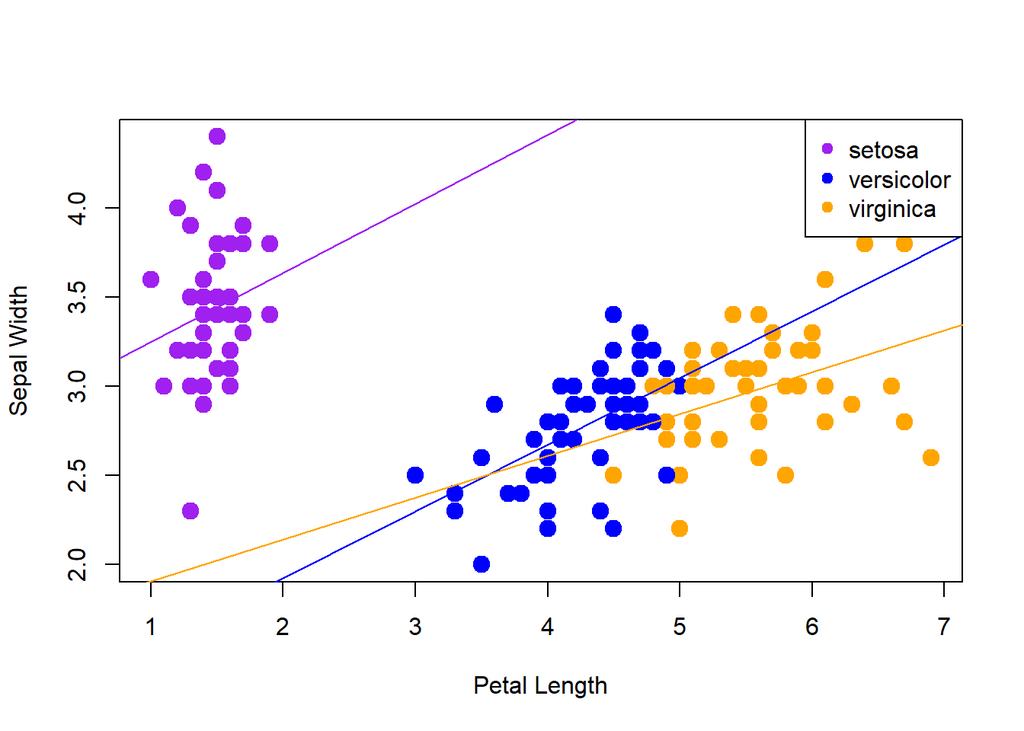

```r
plot(petalL, sepalW, col=color2, cex=1.5, pch=19, xlab="Petal Length", ylab="Sepal Width")
abline(setosaPLvsSW.lm, col="purple")
abline(versicolorPLvsSW.lm, col="blue")
abline(virginicaPLvsSW.lm, col="orange")
legend('topright', legend = levels(species), col = c("purple", "blue", "orange"), cex = 1, pch = 19)
```

What we can see from THIS plot is that, within species, as petal length increases, sepal width ALSO increases. WOW, who would have thought.

And this will conclude my simple anaylsis of the iris dataset!